# How useful are the stats used to calculate Player Rating, actually? - A Data Science Study

edit - I never quite got to the end goal with this project. But a couple of cool anaylses! I built my own xG model (expected goals) and compared the results of different regressions. I also used states of a Markov Chain to determine the value of the ball at each location, in order to determine who is the value of each pass, and then used that data to determine which players provided the most value with their passes

**Importing Data (2 cells)**

## Importing Data

```python
import soccerdata as sd
import pandas as pd
import numpy as np
import matplotlib.pyplot as plt
import seaborn as sns

TEST_PRINT = False
def test_print(x):
    if TEST_PRINT:
        if isinstance(x, pd.DataFrame):
            print(x.head())
        elif isinstance(x, pd.Series):
            print(x.head())
        elif isinstance(x, np.ndarray):
            print(x[:5])
        elif isinstance(x, list):
            print(x[:5])
        else:
            print(x)
```

```python
# Setup a scraper for the 2021/2022 Premier League season
ws = sd.WhoScored(leagues="ENG-Premier League", seasons=2021)
# Scrape all games
api = ws.read_events()
```

**WTF Did I just import - looking at how the data is organized (6 cells)**

### WTF Did I just import - looking at how the data is organized

```python
# lets see all columns, so zero max
pd.set_option("display.max_columns", 0)

ws.leagues
```

```python
#get the data types for each column
api.dtypes
```

```
game_id                int64
period                object
minute                 int64
second               float64
expanded_minute        int64
type                  object
outcome_type          object
team_id                int64
team                  object
player_id            float64
player                object
x                    float64
y                    float64
end_x                float64
end_y                float64
goal_mouth_y         float64
goal_mouth_z         float64
blocked_x            float64
blocked_y            float64
qualifiers            object
is_touch                bool
is_shot               object
is_goal               object
card_type             object
related_event_id     float64
related_player_id    float64
dtype: object
```

```python
api
```

| league | season | game | game_id | period | minute | second | expanded_minute | type | outcome_type | team_id | team | player_id | player | x | y | end_x | end_y | goal_mouth_y | goal_mouth_z | blocked_x | blocked_y | qualifiers | is_touch | is_shot | is_goal | card_type | related_event_id | related_player_id |
| --- | --- | --- | --- | --- | --- | --- | --- | --- | --- | --- | --- | --- | --- | --- | --- | --- | --- | --- | --- | --- | --- | --- | --- | --- | --- | --- | --- | --- |
| ENG-Premier League | 2021 | 2020-09-12 Crystal Palace-Southampton | 1485186 | FirstHalf | 0 | 0.0 | 0 | Start | Successful | 18 | Southampton | NaN | NaN | 0.0 | 0.0 | NaN | NaN | NaN | NaN | NaN | NaN | [] | False | NaN | NaN | NaN | NaN | NaN |
|  |  | 2020-09-12 Crystal Palace-Southampton | 1485186 | FirstHalf | 0 | 0.0 | 0 | Start | Successful | 162 | Crystal Palace | NaN | NaN | 0.0 | 0.0 | NaN | NaN | NaN | NaN | NaN | NaN | [] | False | NaN | NaN | NaN | NaN | NaN |
|  |  | 2020-09-12 Crystal Palace-Southampton | 1485186 | FirstHalf | 0 | 0.0 | 0 | Pass | Successful | 18 | Southampton | 105172.0 | James Ward-Prowse | 49.9 | 50.6 | 32.0 | 46.7 | NaN | NaN | NaN | NaN | [{'type': {'displayName': 'Zone', 'value': 56}... | True | NaN | NaN | NaN | NaN | NaN |
|  |  | 2020-09-12 Crystal Palace-Southampton | 1485186 | FirstHalf | 0 | 2.0 | 0 | Pass | Unsuccessful | 18 | Southampton | 92550.0 | Jack Stephens | 31.8 | 47.2 | 74.4 | 87.1 | NaN | NaN | NaN | NaN | [{'type': {'displayName': 'PassEndY', 'value':... | True | NaN | NaN | NaN | NaN | NaN |
|  |  | 2020-09-12 Crystal Palace-Southampton | 1485186 | FirstHalf | 0 | 5.0 | 0 | Pass | Unsuccessful | 162 | Crystal Palace | 66741.0 | Cheikhou Kouyaté | 27.8 | 19.9 | 41.4 | 21.2 | NaN | NaN | NaN | NaN | [{'type': {'displayName': 'Angle', 'value': 21... | True | NaN | NaN | NaN | NaN | NaN |
|  |  | ... | ... | ... | ... | ... | ... | ... | ... | ... | ... | ... | ... | ... | ... | ... | ... | ... | ... | ... | ... | ... | ... | ... | ... | ... | ... | ... |
|  |  | 2021-05-23 Wolves-Manchester United | 1485563 | SecondHalf | 96 | 51.0 | 102 | End | Successful | 161 | Wolves | NaN | NaN | 0.0 | 0.0 | NaN | NaN | NaN | NaN | NaN | NaN | [] | False | NaN | NaN | NaN | NaN | NaN |
|  |  | 2021-05-23 Wolves-Manchester United | 1485563 | PostGame | 0 | 0.0 | 12 | End | Successful | 161 | Wolves | NaN | NaN | 0.0 | 0.0 | NaN | NaN | NaN | NaN | NaN | NaN | [] | False | NaN | NaN | NaN | NaN | NaN |
|  |  | 2021-05-23 Wolves-Manchester United | 1485563 | PostGame | 0 | 0.0 | 12 | End | Successful | 32 | Man Utd | NaN | NaN | 0.0 | 0.0 | NaN | NaN | NaN | NaN | NaN | NaN | [] | False | NaN | NaN | NaN | NaN | NaN |
|  |  | 2021-05-23 Wolves-Manchester United | 1485563 | PreMatch | 0 | 0.0 | 0 | FormationSet | Successful | 161 | Wolves | NaN | NaN | 0.0 | 0.0 | NaN | NaN | NaN | NaN | NaN | NaN | [{'type': {'displayName': 'JerseyNumber', 'val... | False | NaN | NaN | NaN | NaN | NaN |
|  |  | 2021-05-23 Wolves-Manchester United | 1485563 | PreMatch | 0 | 0.0 | 0 | FormationSet | Successful | 32 | Man Utd | NaN | NaN | 0.0 | 0.0 | NaN | NaN | NaN | NaN | NaN | NaN | [{'type': {'displayName': 'PlayerPosition', 'v... | False | NaN | NaN | NaN | NaN | NaN |

606818 rows × 26 columns

```python
api["type"].unique()
```

```
array(['Start', 'Pass', 'BallRecovery', 'Foul', 'BallTouch',
       'Dispossessed', 'Tackle', 'Aerial', 'CornerAwarded', 'SavedShot',
       'Save', 'KeeperPickup', 'Smother', 'TakeOn', 'Clearance',
       'Challenge', 'Interception', 'Goal', 'BlockedPass', 'OffsideGiven',
       'OffsidePass', 'OffsideProvoked', 'ShieldBallOpp', 'Card',
       'KeeperSweeper', 'End', 'SubstitutionOff', 'SubstitutionOn',
       'Punch', 'MissedShots', 'Claim', 'FormationChange', 'FormationSet',
       'Error', 'ShotOnPost', 'PenaltyFaced', 'CrossNotClaimed',
       'GoodSkill', 'ChanceMissed'], dtype=object)
```

```python
gameId = 1485563
MINUTE = 6

# get rows where the gameId is equal to the gameId variable
game = api[api["game_id"] == gameId]
game[game["minute"] == MINUTE]
```

| league | season | game | game_id | period | minute | second | expanded_minute | type | outcome_type | team_id | team | player_id | player | x | y | end_x | end_y | goal_mouth_y | goal_mouth_z | blocked_x | blocked_y | qualifiers | is_touch | is_shot | is_goal | card_type | related_event_id | related_player_id |
| --- | --- | --- | --- | --- | --- | --- | --- | --- | --- | --- | --- | --- | --- | --- | --- | --- | --- | --- | --- | --- | --- | --- | --- | --- | --- | --- | --- | --- |
| ENG-Premier League | 2021 | 2021-05-23 Wolves-Manchester United | 1485563 | FirstHalf | 6 | 2.0 | 6 | Pass | Successful | 161 | Wolves | 97710.0 | Conor Coady | 29.0 | 46.7 | 27.6 | 83.7 | NaN | NaN | NaN | NaN | [{'type': {'displayName': 'PassEndY', 'value':... | True | NaN | NaN | NaN | NaN | NaN |
|  |  | 2021-05-23 Wolves-Manchester United | 1485563 | FirstHalf | 6 | 4.0 | 6 | Pass | Successful | 161 | Wolves | 97587.0 | Willy-Arnaud Boly | 27.2 | 84.2 | 40.0 | 98.1 | NaN | NaN | NaN | NaN | [{'type': {'displayName': 'Length', 'value': 2... | True | NaN | NaN | NaN | NaN | NaN |
|  |  | 2021-05-23 Wolves-Manchester United | 1485563 | FirstHalf | 6 | 6.0 | 6 | Pass | Unsuccessful | 161 | Wolves | 355401.0 | Rayan Aït-Nouri | 40.2 | 97.5 | 68.0 | 100.0 | NaN | NaN | NaN | NaN | [{'type': {'displayName': 'Zone', 'value': 56}... | True | NaN | NaN | NaN | NaN | NaN |
|  |  | 2021-05-23 Wolves-Manchester United | 1485563 | FirstHalf | 6 | 12.0 | 6 | Pass | Successful | 32 | Man Utd | 243814.0 | Eric Bailly | 33.6 | 0.0 | 41.0 | 7.7 | NaN | NaN | NaN | NaN | [{'type': {'displayName': 'PassEndY', 'value':... | True | NaN | NaN | NaN | NaN | NaN |
|  |  | 2021-05-23 Wolves-Manchester United | 1485563 | FirstHalf | 6 | 14.0 | 6 | Pass | Successful | 32 | Man Utd | 275035.0 | Donny van de Beek | 41.3 | 15.8 | 20.5 | 35.5 | NaN | NaN | NaN | NaN | [{'type': {'displayName': 'Length', 'value': 2... | True | NaN | NaN | NaN | NaN | NaN |
|  |  | 2021-05-23 Wolves-Manchester United | 1485563 | FirstHalf | 6 | 17.0 | 6 | Pass | Successful | 32 | Man Utd | 243814.0 | Eric Bailly | 21.6 | 35.2 | 32.7 | 31.3 | NaN | NaN | NaN | NaN | [{'type': {'displayName': 'PassEndX', 'value':... | True | NaN | NaN | NaN | NaN | NaN |
|  |  | 2021-05-23 Wolves-Manchester United | 1485563 | FirstHalf | 6 | 20.0 | 6 | Pass | Successful | 32 | Man Utd | 38128.0 | Nemanja Matic | 36.4 | 34.9 | 40.8 | 17.7 | NaN | NaN | NaN | NaN | [{'type': {'displayName': 'StandingSave', 'val... | True | NaN | NaN | NaN | NaN | NaN |
|  |  | 2021-05-23 Wolves-Manchester United | 1485563 | FirstHalf | 6 | 22.0 | 6 | Pass | Successful | 32 | Man Utd | 275035.0 | Donny van de Beek | 41.2 | 13.8 | 49.3 | 9.4 | NaN | NaN | NaN | NaN | [{'type': {'displayName': 'Angle', 'value': 21... | True | NaN | NaN | NaN | NaN | NaN |
|  |  | 2021-05-23 Wolves-Manchester United | 1485563 | FirstHalf | 6 | 25.0 | 6 | Pass | Successful | 32 | Man Utd | 386634.0 | Amad Diallo | 51.4 | 8.2 | 37.4 | 32.2 | NaN | NaN | NaN | NaN | [{'type': {'displayName': 'Length', 'value': 2... | True | NaN | NaN | NaN | NaN | NaN |
|  |  | 2021-05-23 Wolves-Manchester United | 1485563 | FirstHalf | 6 | 29.0 | 6 | Pass | Successful | 32 | Man Utd | 38128.0 | Nemanja Matic | 41.1 | 25.8 | 53.8 | 28.3 | NaN | NaN | NaN | NaN | [{'type': {'displayName': 'PassEndX', 'value':... | True | NaN | NaN | NaN | NaN | NaN |
|  |  | 2021-05-23 Wolves-Manchester United | 1485563 | FirstHalf | 6 | 33.0 | 6 | Foul | Successful | 32 | Man Utd | 275035.0 | Donny van de Beek | 56.8 | 33.8 | NaN | NaN | NaN | NaN | NaN | NaN | [{'type': {'displayName': 'OppositeRelatedEven... | True | NaN | NaN | NaN | NaN | NaN |
|  |  | 2021-05-23 Wolves-Manchester United | 1485563 | FirstHalf | 6 | 33.0 | 6 | Foul | Unsuccessful | 161 | Wolves | 238244.0 | Rúben Neves | 43.2 | 66.2 | NaN | NaN | NaN | NaN | NaN | NaN | [{'type': {'displayName': 'StandingSave', 'val... | False | NaN | NaN | NaN | NaN | NaN |
|  |  | 2021-05-23 Wolves-Manchester United | 1485563 | FirstHalf | 6 | 53.0 | 6 | Pass | Successful | 32 | Man Utd | 38128.0 | Nemanja Matic | 56.7 | 33.1 | 63.6 | 18.5 | NaN | NaN | NaN | NaN | [{'type': {'displayName': 'PassEndX', 'value':... | True | NaN | NaN | NaN | NaN | NaN |
|  |  | 2021-05-23 Wolves-Manchester United | 1485563 | FirstHalf | 6 | 58.0 | 6 | Pass | Successful | 32 | Man Utd | 386634.0 | Amad Diallo | 75.9 | 9.8 | 76.3 | 4.0 | NaN | NaN | NaN | NaN | [{'type': {'displayName': 'Length', 'value': 2... | True | NaN | NaN | NaN | NaN | NaN |
|  |  | 2021-05-23 Wolves-Manchester United | 1485563 | FirstHalf | 6 | 59.0 | 6 | Pass | Successful | 32 | Man Utd | 413211.0 | Anthony Elanga | 75.8 | 4.0 | 60.6 | 34.2 | NaN | NaN | NaN | NaN | [{'type': {'displayName': 'Angle', 'value': 21... | True | NaN | NaN | NaN | NaN | NaN |

```python
game[game["is_shot"] == True].iloc[10]['qualifiers']
```

```
[{'type': {'displayName': 'GoalMouthZ', 'value': 103}, 'value': '8.3'},
 {'type': {'displayName': 'MissRight', 'value': 75}},
 {'type': {'displayName': 'IndividualPlay', 'value': 215}},
 {'type': {'displayName': 'GoalMouthY', 'value': 102}, 'value': '1.8'},
 {'type': {'displayName': 'Volley', 'value': 108}},
 {'type': {'displayName': 'StandingSave', 'value': 178}},
 {'type': {'displayName': 'BlockedY', 'value': 147}, 'value': '18.0'},
 {'type': {'displayName': 'Zone', 'value': 56}, 'value': 'Center'},
 {'type': {'displayName': 'OutOfBoxCentre', 'value': 18}},
 {'type': {'displayName': 'RegularPlay', 'value': 22}},
 {'type': {'displayName': 'BlockedX', 'value': 146}, 'value': '85.9'},
 {'type': {'displayName': 'FirstTouch', 'value': 328}},
 {'type': {'displayName': 'RightFoot', 'value': 20}}]
```

```python
shots = api[api["is_shot"] == True]
shots
```

| league | season | game | game_id | period | minute | second | expanded_minute | type | outcome_type | team_id | team | player_id | player | x | y | end_x | end_y | goal_mouth_y | goal_mouth_z | blocked_x | blocked_y | qualifiers | is_touch | is_shot | is_goal | card_type | related_event_id | related_player_id |
| --- | --- | --- | --- | --- | --- | --- | --- | --- | --- | --- | --- | --- | --- | --- | --- | --- | --- | --- | --- | --- | --- | --- | --- | --- | --- | --- | --- | --- |
| ENG-Premier League | 2021 | 2020-09-12 Crystal Palace-Southampton | 1485186 | FirstHalf | 3 | 21.0 | 3 | SavedShot | Successful | 18 | Southampton | 92550.0 | Jack Stephens | 91.7 | 47.2 | NaN | NaN | 52.3 | 12.0 | 98.8 | 48.9 | [{'type': {'displayName': 'FromCorner', 'value... | True | True | NaN | NaN | 36.0 | 105172.0 |
|  |  | 2020-09-12 Crystal Palace-Southampton | 1485186 | FirstHalf | 12 | 34.0 | 12 | Goal | Successful | 162 | Crystal Palace | 85059.0 | Wilfried Zaha | 92.0 | 56.1 | NaN | NaN | 52.8 | 6.3 | NaN | NaN | [{'type': {'displayName': 'GoalMouthY', 'value... | True | True | True | NaN | 97.0 | 71522.0 |
|  |  | 2020-09-12 Crystal Palace-Southampton | 1485186 | FirstHalf | 31 | 5.0 | 31 | SavedShot | Successful | 18 | Southampton | 91762.0 | Danny Ings | 97.0 | 32.4 | NaN | NaN | 45.4 | 12.7 | 99.4 | 44.9 | [{'type': {'displayName': 'LowRight', 'value':... | True | True | NaN | NaN | NaN | NaN |
|  |  | 2020-09-12 Crystal Palace-Southampton | 1485186 | FirstHalf | 35 | 6.0 | 35 | SavedShot | Successful | 162 | Crystal Palace | 66741.0 | Cheikhou Kouyaté | 90.5 | 51.1 | NaN | NaN | 49.3 | 2.5 | 97.7 | 50.4 | [{'type': {'displayName': 'RelatedEventId', 'v... | True | True | NaN | NaN | 260.0 | 71522.0 |
|  |  | 2020-09-12 Crystal Palace-Southampton | 1485186 | SecondHalf | 45 | 48.0 | 48 | SavedShot | Successful | 18 | Southampton | 86425.0 | Nathan Redmond | 87.9 | 60.6 | NaN | NaN | 50.0 | 3.8 | 98.6 | 52.0 | [{'type': {'displayName': 'BoxCentre', 'value'... | True | True | NaN | NaN | 540.0 | 256419.0 |
|  |  | ... | ... | ... | ... | ... | ... | ... | ... | ... | ... | ... | ... | ... | ... | ... | ... | ... | ... | ... | ... | ... | ... | ... | ... | ... | ... | ... |
|  |  | 2021-05-23 Wolves-Manchester United | 1485563 | SecondHalf | 78 | 54.0 | 84 | MissedShots | Successful | 161 | Wolves | 238244.0 | Rúben Neves | 73.5 | 56.5 | NaN | NaN | 59.3 | 8.3 | NaN | NaN | [{'type': {'displayName': 'StandingSave', 'val... | True | True | NaN | NaN | 773.0 | 16161.0 |
|  |  | 2021-05-23 Wolves-Manchester United | 1485563 | SecondHalf | 80 | 27.0 | 86 | SavedShot | Successful | 32 | Man Utd | 386634.0 | Amad Diallo | 77.2 | 60.8 | NaN | NaN | 47.0 | 6.3 | 98.4 | 51.1 | [{'type': {'displayName': 'BlockedX', 'value':... | True | True | NaN | NaN | 727.0 | 302313.0 |
|  |  | 2021-05-23 Wolves-Manchester United | 1485563 | SecondHalf | 82 | 51.0 | 88 | SavedShot | Successful | 161 | Wolves | 332867.0 | Morgan Gibbs-White | 86.4 | 45.2 | NaN | NaN | 47.2 | 29.1 | 98.5 | 48.7 | [{'type': {'displayName': 'RelatedEventId', 'v... | True | True | NaN | NaN | 810.0 | 238244.0 |
|  |  | 2021-05-23 Wolves-Manchester United | 1485563 | SecondHalf | 90 | 48.0 | 96 | MissedShots | Successful | 161 | Wolves | 332867.0 | Morgan Gibbs-White | 74.0 | 52.2 | NaN | NaN | 58.7 | 6.9 | NaN | NaN | [{'type': {'displayName': 'RelatedEventId', 'v... | True | True | NaN | NaN | 886.0 | 236519.0 |
|  |  | 2021-05-23 Wolves-Manchester United | 1485563 | SecondHalf | 94 | 16.0 | 100 | MissedShots | Successful | 161 | Wolves | 97587.0 | Willy-Arnaud Boly | 70.1 | 54.8 | NaN | NaN | 40.2 | 59.7 | NaN | NaN | [{'type': {'displayName': 'StandingSave', 'val... | True | True | NaN | NaN | 920.0 | 121718.0 |

9212 rows × 26 columns

```python
# get rid of columns except for is_goal, x, y, and qualifiers
shots
```

| league | season | game | game_id | period | minute | second | expanded_minute | type | outcome_type | team_id | team | player_id | player | x | y | end_x | end_y | goal_mouth_y | goal_mouth_z | blocked_x | blocked_y | qualifiers | is_touch | is_shot | is_goal | card_type | related_event_id | related_player_id |
| --- | --- | --- | --- | --- | --- | --- | --- | --- | --- | --- | --- | --- | --- | --- | --- | --- | --- | --- | --- | --- | --- | --- | --- | --- | --- | --- | --- | --- |
| ENG-Premier League | 2021 | 2020-09-12 Crystal Palace-Southampton | 1485186 | FirstHalf | 3 | 21.0 | 3 | SavedShot | Successful | 18 | Southampton | 92550.0 | Jack Stephens | 91.7 | 47.2 | NaN | NaN | 52.3 | 12.0 | 98.8 | 48.9 | [{'type': {'displayName': 'FromCorner', 'value... | True | True | NaN | NaN | 36.0 | 105172.0 |
|  |  | 2020-09-12 Crystal Palace-Southampton | 1485186 | FirstHalf | 12 | 34.0 | 12 | Goal | Successful | 162 | Crystal Palace | 85059.0 | Wilfried Zaha | 92.0 | 56.1 | NaN | NaN | 52.8 | 6.3 | NaN | NaN | [{'type': {'displayName': 'GoalMouthY', 'value... | True | True | True | NaN | 97.0 | 71522.0 |
|  |  | 2020-09-12 Crystal Palace-Southampton | 1485186 | FirstHalf | 31 | 5.0 | 31 | SavedShot | Successful | 18 | Southampton | 91762.0 | Danny Ings | 97.0 | 32.4 | NaN | NaN | 45.4 | 12.7 | 99.4 | 44.9 | [{'type': {'displayName': 'LowRight', 'value':... | True | True | NaN | NaN | NaN | NaN |
|  |  | 2020-09-12 Crystal Palace-Southampton | 1485186 | FirstHalf | 35 | 6.0 | 35 | SavedShot | Successful | 162 | Crystal Palace | 66741.0 | Cheikhou Kouyaté | 90.5 | 51.1 | NaN | NaN | 49.3 | 2.5 | 97.7 | 50.4 | [{'type': {'displayName': 'RelatedEventId', 'v... | True | True | NaN | NaN | 260.0 | 71522.0 |
|  |  | 2020-09-12 Crystal Palace-Southampton | 1485186 | SecondHalf | 45 | 48.0 | 48 | SavedShot | Successful | 18 | Southampton | 86425.0 | Nathan Redmond | 87.9 | 60.6 | NaN | NaN | 50.0 | 3.8 | 98.6 | 52.0 | [{'type': {'displayName': 'BoxCentre', 'value'... | True | True | NaN | NaN | 540.0 | 256419.0 |
|  |  | ... | ... | ... | ... | ... | ... | ... | ... | ... | ... | ... | ... | ... | ... | ... | ... | ... | ... | ... | ... | ... | ... | ... | ... | ... | ... | ... |
|  |  | 2021-05-23 Wolves-Manchester United | 1485563 | SecondHalf | 78 | 54.0 | 84 | MissedShots | Successful | 161 | Wolves | 238244.0 | Rúben Neves | 73.5 | 56.5 | NaN | NaN | 59.3 | 8.3 | NaN | NaN | [{'type': {'displayName': 'StandingSave', 'val... | True | True | NaN | NaN | 773.0 | 16161.0 |
|  |  | 2021-05-23 Wolves-Manchester United | 1485563 | SecondHalf | 80 | 27.0 | 86 | SavedShot | Successful | 32 | Man Utd | 386634.0 | Amad Diallo | 77.2 | 60.8 | NaN | NaN | 47.0 | 6.3 | 98.4 | 51.1 | [{'type': {'displayName': 'BlockedX', 'value':... | True | True | NaN | NaN | 727.0 | 302313.0 |
|  |  | 2021-05-23 Wolves-Manchester United | 1485563 | SecondHalf | 82 | 51.0 | 88 | SavedShot | Successful | 161 | Wolves | 332867.0 | Morgan Gibbs-White | 86.4 | 45.2 | NaN | NaN | 47.2 | 29.1 | 98.5 | 48.7 | [{'type': {'displayName': 'RelatedEventId', 'v... | True | True | NaN | NaN | 810.0 | 238244.0 |
|  |  | 2021-05-23 Wolves-Manchester United | 1485563 | SecondHalf | 90 | 48.0 | 96 | MissedShots | Successful | 161 | Wolves | 332867.0 | Morgan Gibbs-White | 74.0 | 52.2 | NaN | NaN | 58.7 | 6.9 | NaN | NaN | [{'type': {'displayName': 'RelatedEventId', 'v... | True | True | NaN | NaN | 886.0 | 236519.0 |
|  |  | 2021-05-23 Wolves-Manchester United | 1485563 | SecondHalf | 94 | 16.0 | 100 | MissedShots | Successful | 161 | Wolves | 97587.0 | Willy-Arnaud Boly | 70.1 | 54.8 | NaN | NaN | 40.2 | 59.7 | NaN | NaN | [{'type': {'displayName': 'StandingSave', 'val... | True | True | NaN | NaN | 920.0 | 121718.0 |

9212 rows × 26 columns

```python
import math

def isHeader(qualifiers):
    for q in qualifiers:
        if q["type"]["displayName"] == "Header":
            return True
    return False

def isVolley(qualifiers):
    for q in qualifiers:
        if q["type"]["displayName"] == "Volley":
            return True
    return False

def isPenalty(qualifiers):
    for q in qualifiers:
        if q["type"]["displayName"] == "Penalty":
            return True
    return False

def isOwnGoal(qualifiers):
    for q in qualifiers:
        if q["type"]["displayName"] == "OwnGoal":
            return True
    return False

def isGoal(og_is_goal):
    if og_is_goal == True:
        return 1
    else:
        return 0

# instead of x and y, we will use the distance from the center of the goal and


def getDistance(x, y):
    return np.sqrt((x - 100) ** 2 + (y - 50) ** 2)

# the angle formed by the
# goalposts (100, 45) and (100, 55) and the shot location
def compute_angle(x: float, y: float) -> float:
    # unsquish x so that 50 = 100 - (55/36) * (100-x)
    x = 100 - (55/36) * (100-x)

    # Define points
    x1, y1 = 100, 45
    x2, y2 = 100, 55

    # Define vectors A and B
    ax, ay = x1 - x, y1 - y
    bx, by = x2 - x, y2 - y

    # Compute dot product
    dot_product = ax * bx + ay * by

    # Compute magnitudes
    mag_a = math.sqrt(ax**2 + ay**2)
    mag_b = math.sqrt(bx**2 + by**2)

    # Compute cosine of the angle
    cos_theta = dot_product / (mag_a * mag_b)

    # Avoid precision errors outside valid range
    cos_theta = max(-1, min(1, cos_theta))

    # Compute angle in radians and convert to degrees
    theta = math.degrees(math.acos(cos_theta))

    return theta

test_cases = [
        (100, 50, 180),  # Directly between the two points
        (90, 50, 37),    # Penalty spot
        (90 + (50/11), 62.5, 23),   # corner of the 6 yard box
    ]

for x, y, expected in test_cases:
    result = compute_angle(x, y)
    print(f"compute_angle({x}, {y}) = {result:.2f} (Expected: {expected})")
    assert math.isclose(result, expected, rel_tol=1), f"Failed for ({x}, {y})"
```

```
compute_angle(100, 50) = 180.00 (Expected: 180)
compute_angle(90, 50) = 36.24 (Expected: 37)
compute_angle(94.54545454545455, 62.5) = 22.55 (Expected: 23)
```

```python
# create a new column called is_header and apply the isHeader function to the qualifiers column
shots["is_header"] = shots["qualifiers"].apply(isHeader)
shots["is_volley"] = shots["qualifiers"].apply(isVolley)
shots["is_goal"] = shots["is_goal"].apply(isGoal)
shots["distance"] = shots.apply(lambda x: getDistance(x["x"], x["y"]), axis=1)
shots["angle"] = shots.apply(lambda x: compute_angle(x["x"], x["y"]), axis=1)
shots["is_penalty"] = shots["qualifiers"].apply(isPenalty)
shots["is_own_goal"] = shots["qualifiers"].apply(isOwnGoal)

#now remove the qualifiers column
shots = shots[shots["is_penalty"] == False]
shots = shots[shots["is_own_goal"] == False]
# shots[shots["distance"] > 30]
```

```python
# now, use logistic regression to generate an XG model
from sklearn.linear_model import LogisticRegression
from sklearn.model_selection import train_test_split
from sklearn.metrics import accuracy_score
import xgboost as xgb

# split the data into training and testing sets
X_train, X_test, y_train, y_test = train_test_split(shots[["distance", "angle", "is_header", "is_volley"]], shots["is_goal"], test_size=0.2)

# create an xgboost model
model = LogisticRegression()


model.fit(X_train, y_train)

# predict the test data
y_pred = model.predict(X_test)

# calculate the accuracy of the model
print(accuracy_score(y_test, y_pred))

# get the feature importances
# model.feature_importances_

# plot the feature importances
# plt.bar(X_train.columns, model.feature_importances_)
```

```
0.9066298342541437
```

[output not shown]

[output cut: 19947 more lines]

[output not shown]

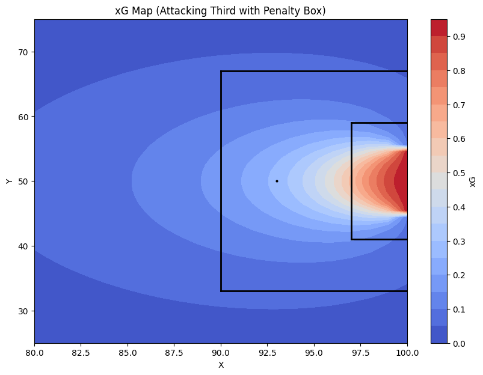

```python
#given xGB model, I want a visualization of the xG map, given distance and angle
#I want to create a 2D grid of the pitch, and for each point in the grid, I want to calculate the xG value
#I will then plot the xG values on the pitch

# create a 2D grid of the pitch
x = np.linspace(0, 100, 100)
y = np.linspace(0, 100, 100)
X, Y = np.meshgrid(x, y)

# calculate the xG value for each point in the grid
Z = np.zeros(X.shape)
for i in range(X.shape[0]):
    for j in range(X.shape[1]):
        distance = np.sqrt((X[i, j] - 100) ** 2 + (Y[i, j] - 50) ** 2)
        angle = compute_angle(X[i, j], Y[i, j])
        is_header = False
        is_volley = False
        xg = model.predict_proba([[distance, angle, is_header, is_volley]])[0][1]
        Z[i, j] = xg

# plot the xG values on the pitch, constrained to the attacking third and box
plt.figure(figsize=(10, 7))

# Limit the plot to the attacking third and the box area
plt.contourf(X, Y, Z, cmap="coolwarm", levels=20)
plt.colorbar(label="xG")
plt.xlabel("X")
plt.ylabel("Y")

# Draw the penalty box: x=90, y=33 to y=67
plt.plot([90, 90], [33, 67], color='black', linewidth=2)  # vertical line (box edge)
plt.plot([90, 100], [33, 33], color='black', linewidth=2) # bottom line
plt.plot([90, 100], [67, 67], color='black', linewidth=2) # top line

# Draw the smaller goalie box: x=97, y=44 to y=56
plt.plot([97, 97], [41, 59], color='black', linewidth=2)  # vertical line (goalie box edge)
plt.plot([97, 100], [41, 41], color='black', linewidth=2) # bottom line
plt.plot([97, 100], [59, 59], color='black', linewidth=2) # top line

# Draw the penalty spot
plt.plot(93, 50, 'ro', color='black', markersize=2)  # penalty spot

plt.xlim(80, 100)
plt.ylim(25, 75)

plt.title("xG Map (Attacking Third with Penalty Box)")
plt.show()
```

**Deriving a Positional Expected Goals based on ball position (1 cell)**

## Deriving a Positional Expected Goals based on ball position

In order to show what actions are likely to lead to shots, I have to create a stat, similar to xG, which shows the expected likelyhood of the team scoring based on the action shown. In order to backderive this we must first add the data point of when the next goal was scored (and by whom)into the dataframe.

```python
# split goals into a dictionary based on gameId so it can be accessed by gameId in linear time
shots_dict = dict(tuple(shots.groupby("game_id")))
# shots_dict
```

**Using Linear Regression (4 cells)**

### Using Linear Regression

```python
TIME_UNTIL_NEXT_SHOT = 2 # if no shot is taken by then, return 0
#measured in minutes

def getxGNextShot(moment, shots_dict):
    # get the game_id, team_name, time_min, and time_sec from the moment
    game_id = moment["game_id"]
    half = moment["period"]
    team_name = moment["team"]
    time_min = moment["minute"]
    time_sec = moment["second"]
    # get shots from the game
    game_shots = pd.DataFrame()
    if game_id in shots_dict:
        game_shots = shots_dict[game_id]
    # get shots that happened after the time_min and time_sec, but within recency as measured by
    # TIME_UNTIL_NEXT_SHOT
        game_shots = game_shots[
        ((game_shots["minute"] > time_min)
        | ((game_shots["minute"] == time_min) & (game_shots["second"] > time_sec)))
        & (game_shots["period"] == half) &
        ((game_shots["minute"] <= time_min + TIME_UNTIL_NEXT_SHOT)
        | ((game_shots["minute"] == time_min + TIME_UNTIL_NEXT_SHOT) & (game_shots["second"] <= time_sec)))]
    # if there are no shots after the time_min and time_sec, return 0
    if len(game_shots) == 0:
        return 0
    # get the first shot that happened after the time_min and time_sec
    shot = game_shots.iloc[0]
    # return the minute of the goal
    team = 1 if shot["team"] == team_name else -1
    return team * (model.predict_proba([[shot["distance"], shot["angle"], shot["is_header"], shot["is_volley"]]])[0][1])
```

```python
GAMES_SAMPLE_SIZE = 50

# let's cut api into 10 games so that running analysis is faster
games = api["game_id"].unique()
games = np.array_split(games, len(games) // GAMES_SAMPLE_SIZE)

first_ten_games = api[api["game_id"].isin(games[0])]
first_ten_games["next_shot"] = first_ten_games.apply(lambda x: getxGNextShot(x, shots_dict), axis=1)
first_ten_games["distance"] = first_ten_games.apply(lambda x: getDistance(x["x"], x["y"]), axis=1)
first_ten_games["angle"] = first_ten_games.apply(lambda x: compute_angle(x["x"], x["y"]), axis=1)

# first_ten_games
```

```python
from sklearn.linear_model import LinearRegression
from sklearn.model_selection import train_test_split
from sklearn.metrics import accuracy_score

X_train, X_test, y_train, y_test = train_test_split(first_ten_games[["distance", "angle"]], first_ten_games["next_shot"], test_size=0.2)

# create an Logistic Regression model
model_posValue = LinearRegression()


model_posValue.fit(X_train, y_train)

# predict the test data
y_pred = model_posValue.predict(X_test)

# calculate the sqrt error of the Linear Regression model
print(np.sqrt(np.mean((y_test - y_pred) ** 2)))

# get coefficients of the model
model_posValue.coef_
```

```
0.08339422052690519
```

```
array([-0.00059646, -0.0004511 ])
```

[output not shown]

[output cut: 39945 more lines]

[output not shown]

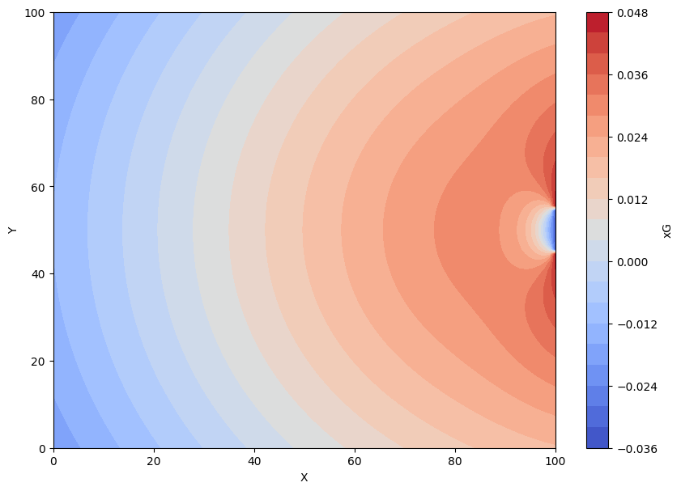

```python
#given xGB model, I want a visualization of the xG map, given distance and angle
#I want to create a 2D grid of the pitch, and for each point in the grid, I want to calculate the xG value
#I will then plot the xG values on the pitch

# create a 2D grid of the pitch
x = np.linspace(0, 100, 100)
y = np.linspace(0, 100, 100)
X, Y = np.meshgrid(x, y)

# calculate the xG value for each point in the grid
Z = np.zeros(X.shape)
for i in range(X.shape[0]):
    for j in range(X.shape[1]):
        distance = np.sqrt((X[i, j] - 100) ** 2 + (Y[i, j] - 50) ** 2)
        angle = compute_angle(X[i, j], Y[i, j])
        is_header = False
        is_volley = False
        xv = model_posValue.predict([[distance, angle]])
        Z[i, j] = xv

# plot the xG values on the pitch
plt.figure(figsize=(10, 7))
plt.contourf(X, Y, Z, cmap="coolwarm", levels=20)
plt.colorbar(label="xG")
plt.xlabel("X")
plt.ylabel("Y")

plt.show()
```

**Using a Markov Chain (0 cells)**

### Using a Markov Chain

While the results shown aren't exactly shocking, I think this is an error on my part. We should analyze this as if it is a Markov Chain (grouping each part of the pitch as it's own state) and then find the expected value of each state dependant on the expected value of the output.

**Filtering the Data Into Passes and Shots Only (3 cells)**

#### Filtering the Data Into Passes and Shots Only

The goal here is to remove data (subsitutions formations etc) irrelevant to developing our expected value out of the dataset

```python
TEST_PRINT=True
GAMES_SAMPLE_SIZE = 50
#choose 10 games from the first ten games
# let's cut api into 10 games so that running analysis is faster
games = api["game_id"].unique()
games = np.array_split(games, len(games) // GAMES_SAMPLE_SIZE)

sample = api[api["game_id"].isin(games[0])]
sample = api #no sample, comment to undo

print("All Types of Events in Sample:")
test_print(sample["type"].unique())
print('------------')
# keep it super simple, for now
events_to_keep = ["Pass", "Goal"]
markov = sample[sample["type"].isin(events_to_keep)]

# print all the column names
print("Columns in Sample:")
test_print(markov.columns)
```

```
All Types of Events in Sample:
['Start' 'Pass' 'BallRecovery' 'Foul' 'BallTouch']
------------
Columns in Sample:
Index(['game_id', 'period', 'minute', 'second', 'expanded_minute', 'type',
       'outcome_type', 'team_id', 'team', 'player_id', 'player', 'x', 'y',
       'end_x', 'end_y', 'goal_mouth_y', 'goal_mouth_z', 'blocked_x',
       'blocked_y', 'qualifiers', 'is_touch', 'is_shot', 'is_goal',
       'card_type', 'related_event_id', 'related_player_id'],
      dtype='object')
```

```python
event = "Goal"
sample[sample["type"] == event]
```

| league | season | game | game_id | period | minute | second | expanded_minute | type | outcome_type | team_id | team | player_id | player | x | y | end_x | end_y | goal_mouth_y | goal_mouth_z | blocked_x | blocked_y | qualifiers | is_touch | is_shot | is_goal | card_type | related_event_id | related_player_id |
| --- | --- | --- | --- | --- | --- | --- | --- | --- | --- | --- | --- | --- | --- | --- | --- | --- | --- | --- | --- | --- | --- | --- | --- | --- | --- | --- | --- | --- |
| ENG-Premier League | 2021 | 2020-09-12 Crystal Palace-Southampton | 1485186 | FirstHalf | 12 | 34.0 | 12 | Goal | Successful | 162 | Crystal Palace | 85059.0 | Wilfried Zaha | 92.0 | 56.1 | NaN | NaN | 52.8 | 6.3 | NaN | NaN | [{'type': {'displayName': 'GoalMouthY', 'value... | True | True | True | NaN | 97.0 | 71522.0 |
|  |  | 2020-09-12 Fulham-Arsenal | 1485187 | FirstHalf | 7 | 59.0 | 7 | Goal | Successful | 13 | Arsenal | 73078.0 | Alexandre Lacazette | 97.4 | 47.0 | NaN | NaN | 45.9 | 3.8 | NaN | NaN | [{'type': {'displayName': 'RegularPlay', 'valu... | True | True | True | NaN | NaN | NaN |
|  |  | 2020-09-12 Fulham-Arsenal | 1485187 | SecondHalf | 48 | 37.0 | 50 | Goal | Successful | 13 | Arsenal | 334087.0 | Gabriel Magalhães | 94.9 | 48.2 | NaN | NaN | 49.7 | 6.3 | NaN | NaN | [{'type': {'displayName': 'BigChance', 'value'... | True | True | True | NaN | 494.0 | 29463.0 |
|  |  | 2020-09-12 Fulham-Arsenal | 1485187 | SecondHalf | 56 | 38.0 | 58 | Goal | Successful | 13 | Arsenal | 44120.0 | Pierre-Emerick Aubameyang | 87.2 | 63.6 | NaN | NaN | 46.7 | 25.3 | NaN | NaN | [{'type': {'displayName': 'GoalMouthY', 'value... | True | True | True | NaN | 553.0 | 29463.0 |
|  |  | 2020-09-12 Liverpool-Leeds | 1485188 | FirstHalf | 3 | 58.0 | 3 | Goal | Successful | 26 | Liverpool | 108226.0 | Mohamed Salah | 88.5 | 50.0 | NaN | NaN | 50.0 | 26.6 | NaN | NaN | [{'type': {'displayName': 'StandingSave', 'val... | True | True | True | NaN | NaN | NaN |
|  |  | ... | ... | ... | ... | ... | ... | ... | ... | ... | ... | ... | ... | ... | ... | ... | ... | ... | ... | ... | ... | ... | ... | ... | ... | ... | ... | ... |
|  |  | 2021-05-23 West Ham-Southampton | 1485562 | FirstHalf | 32 | 27.0 | 32 | Goal | Successful | 29 | West Ham | 297203.0 | Pablo Fornals | 90.0 | 43.1 | NaN | NaN | 45.9 | 3.2 | NaN | NaN | [{'type': {'displayName': 'Zone', 'value': 56}... | True | True | True | NaN | 293.0 | 111372.0 |
|  |  | 2021-05-23 West Ham-Southampton | 1485562 | SecondHalf | 85 | 16.0 | 87 | Goal | Successful | 29 | West Ham | 332325.0 | Declan Rice | 91.5 | 63.3 | NaN | NaN | 52.9 | 1.3 | NaN | NaN | [{'type': {'displayName': 'Zone', 'value': 56}... | True | True | True | NaN | 643.0 | 297203.0 |
|  |  | 2021-05-23 Wolves-Manchester United | 1485563 | FirstHalf | 12 | 19.0 | 12 | Goal | Successful | 32 | Man Utd | 413211.0 | Anthony Elanga | 92.7 | 49.0 | NaN | NaN | 52.8 | 18.4 | NaN | NaN | [{'type': {'displayName': 'LowLeft', 'value': ... | True | True | True | NaN | 110.0 | 302313.0 |
|  |  | 2021-05-23 Wolves-Manchester United | 1485563 | FirstHalf | 38 | 40.0 | 38 | Goal | Successful | 161 | Wolves | 296363.0 | Nélson Semedo | 93.2 | 45.5 | NaN | NaN | 53.4 | 3.2 | NaN | NaN | [{'type': {'displayName': 'Assisted', 'value':... | True | True | True | NaN | 345.0 | 380655.0 |
|  |  | 2021-05-23 Wolves-Manchester United | 1485563 | FirstHalf | 48 | 57.0 | 48 | Goal | Successful | 32 | Man Utd | 25363.0 | Juan Mata | 88.5 | 50.0 | NaN | NaN | 53.9 | 21.5 | NaN | NaN | [{'type': {'displayName': 'LeftFoot', 'value':... | True | True | True | NaN | NaN | NaN |

1020 rows × 26 columns

```python
# MINUTE = 78
# # get all events that happened in the first minute
# game[game["minute"] == MINUTE]
```

**Doing The Actual Math (4 cells)**

#### Doing The Actual Math

```python
PORTIONS_OF_PITCH_LENGTHWISE = 10  # Each state has three portions of the pitch
PORTIONS_OF_PITCH_WIDTHWISE = 6  # Each state has three portions of the pitch widthwise
PORTIONS_OF_PITCH = PORTIONS_OF_PITCH_LENGTHWISE * PORTIONS_OF_PITCH_WIDTHWISE

# PROMPT to have Chat generate the constants:
# generate home and away constants for the following Markov Chain states: goal, successful pass, unsuccessful pass
HOME_GOAL = 0
AWAY_GOAL = 1
# NOTE: Using three numbers for each state to represent each third of the pitch
HOME_TEAM_SUCCESSFUL_PASS = 2
AWAY_TEAM_SUCCESSFUL_PASS = 3
FINAL_MARKOV_CHAIN_SIZE = 2 + 2 * PORTIONS_OF_PITCH  # 2 goals + 2 states for each portion of the pitch


transition_matrix = np.zeros((FINAL_MARKOV_CHAIN_SIZE, FINAL_MARKOV_CHAIN_SIZE))
transition_matrix[HOME_GOAL][HOME_GOAL] = 1
transition_matrix[AWAY_GOAL][AWAY_GOAL] = 1

def get_portion_of_pitch(x, y):
    """
    Given an event, return the key for the state at the beginning of the event.
    ie. if the event is a goal, return the state before the shot was taken(ball in box etc.)
    assume the home team has the ball
    """
    x_added_term = (x // (100.01 / PORTIONS_OF_PITCH_LENGTHWISE)) * PORTIONS_OF_PITCH_WIDTHWISE
    y_added_term = (y // (100.01 / PORTIONS_OF_PITCH_WIDTHWISE))
    return int(HOME_TEAM_SUCCESSFUL_PASS + 2*(x_added_term + y_added_term))

# Should print
print(get_portion_of_pitch(99, 50))  # In front of goal

def reciporical(state):
    """
    Create a function that, given 0 returns 1, given 1 returns 0, etc
    """
    return state+1 if state % 2 == 0 else state-1

def get_starting_state(event, away_team):
    """
    Given an event, return the key for the state at the beginning of the event.
    """
    ans = get_portion_of_pitch(event["x"], event["y"])
    return ans if event["team"] != away_team else reciporical(ans)

def get_ending_state(event, away_team):
    ans = FINAL_MARKOV_CHAIN_SIZE
    if event["type"] == "Goal":
        ans = HOME_GOAL
    else:
        if event["outcome_type"] == "Successful":
            ans = get_portion_of_pitch(event["end_x"], event["end_y"])
        else:
            ans = reciporical(get_portion_of_pitch(100-event["end_x"], 100-event["end_y"]))

    return ans if event["team"] != away_team else reciporical(ans)
```

```
114
```

```python
def normalize_transition_matrix(matrix):
    """Normalize the transition matrix so that each row sums to 1.
    In addition, keep a list that contains value counts for each state, for later use.
    """
    row_sums = matrix.sum(axis=1, keepdims=True)
    return row_sums, matrix / row_sums

def set_initial_state(first_state):

    """
    2021-05-23 Wolves-Manchester United
    Given a game string like "2021-05-23 Manchester City-Manchester United", return a list with the away team at 0 and home at 1, such as ["Wolves", "Manchester United"].
    """
    def get_game_teams_from_string(game_string):
        team_names = " ".join(game_string.split(" ")[1:])
        #turn this list into a string with spaces between the words
        parts = team_names.split("-")
        return parts[0]


    def get_match_name(first_state):
        return first_state.name[2]  # The match name is the second part of the index tuple


    match_name = get_match_name(first_state)
    away_team = get_game_teams_from_string(match_name)
    if first_state["team"] == away_team:
        return first_state["game_id"], away_team, get_starting_state(first_state, away_team)
    else:
        return first_state["game_id"], away_team, get_starting_state(first_state, away_team)
```

```python
TEST_PRINT = True
RECIPROCITY = True  # at this point, the code probably would fail if this was set to False
#next, we will iterate through the events in the game and update the transition matrix

def update_transition_matrix(transition_matrix, start_state, end_state):
    if start_state not in [HOME_GOAL, AWAY_GOAL]: #these two are terminal states
        test_print(f"Transitioning from state {start_state} to {end_state}")
        transition_matrix[start_state][end_state] += 1
        if RECIPROCITY:
            transition_matrix[reciporical(start_state)][reciporical(end_state)] += 1
    return transition_matrix

def set_transition_matrix(transition_matrix, list_of_events):
    """
    Given a list of events (possibly over multiple games),
    update the transition matrix based on the states that occur during the game.
    :param transition_matrix: The transition matrix to update.
    :param list_of_events: A DataFrame containing the events of the game.
    :return: The updated transition matrix, normalized so all rows add to one, and a list of pre-normalized row sums.
    """
    game_id, away_team, state = set_initial_state(list_of_events.iloc[0])
    for _, event in list_of_events.iterrows():
        if event["minute"] == MINUTE:
            # if the event is in the first minute, we can skip it
            test_print(f"Processing event: {event['type']}{event['outcome_type']}, {event['x']}:{event['y']} to {event['end_x']}:{event['end_y']}")

        if event["game_id"] != game_id:
            # if the game_id changes, we need to reset the state
            game_id, away_team, state = set_initial_state(event)
        else:
            start_state = get_starting_state(event, away_team)
            transition_matrix = update_transition_matrix(transition_matrix, state, start_state)
            state = start_state

        # Ending state as well
        end_state = get_ending_state(event, away_team)
        transition_matrix = update_transition_matrix(transition_matrix, state, end_state)
        state = end_state


    test_print(transition_matrix)
    row_sums, new_matrix = normalize_transition_matrix(transition_matrix)
    return row_sums, new_matrix

instance_counts,transition_matrix = set_transition_matrix(transition_matrix, markov)
# print the transition matrix
print("Transition Matrix:")
print(transition_matrix)
```

```
[[  1.   0.   0.   0.   0.   0.   0.   0.   0.   0.   0.   0.   0.   0.
    0.   0.   0.   0.   0.   0.   0.   0.   0.   0.   0.   0.   0.   0.
    0.   0.   0.   0.   0.   0.   0.   0.   0.   0.   0.   0.   0.   0.
    0.   0.   0.   0.   0.   0.   0.   0.   0.   0.   0.   0.   0.   0.
    0.   0.   0.   0.   0.   0.   0.   0.   0.   0.   0.   0.   0.   0.
    0.   0.   0.   0.   0.   0.   0.   0.   0.   0.   0.   0.   0.   0.
    0.   0.   0.   0.   0.   0.   0.   0.   0.   0.   0.   0.   0.   0.
    0.   0.   0.   0.   0.   0.   0.   0.   0.   0.   0.   0.   0.   0.
    0.   0.   0.   0.   0.   0.   0.   0.   0.   0.]
 [  0.   1.   0.   0.   0.   0.   0.   0.   0.   0.   0.   0.   0.   0.
    0.   0.   0.   0.   0.   0.   0.   0.   0.   0.   0.   0.   0.   0.
    0.   0.   0.   0.   0.   0.   0.   0.   0.   0.   0.   0.   0.   0.
    0.   0.   0.   0.   0.   0.   0.   0.   0.   0.   0.   0.   0.   0.
    0.   0.   0.   0.   0.   0.   0.   0.   0.   0.   0.   0.   0.   0.
    0.   0.   0.   0.   0.   0.   0.   0.   0.   0.   0.   0.   0.   0.
    0.   0.   0.   0.   0.   0.   0.   0.   0.   0.   0.   0.   0.   0.
    0.   0.   0.   0.   0.   0.   0.   0.   0.   0.   0.   0.   0.   0.
    0.   0.   0.   0.   0.   0.   0.   0.   0.   0.]
 [  0.   0. 594.  33. 107.   5. 186.  33.  47.  13.   0.   0.   0.   0.
  342.  23.  66.   4.  17.   0.   1.   0.   1.   0.   0.   0. 122.   6.
   26.   0.   3.   0.   0.   1.   2.   4.   1.   2.  48.   0.  16.   0.
    4.   2.   0.   2.   1.  10.   0.   9.  20.   1.  14.   0.   3.   0.
    1.   5.   0.  16.   0.  30.   4.   0.   3.   0.   2.   0.   0.   8.
    0.  28.   0.  75.   0.   0.   2.   0.   0.   1.   0.   3.   0.  40.
    0. 110.   0.   1.   0.   0.   0.   0.   0.   1.   0.  15.   0. 119.
    0.   0.   0.   0.   0.   0.   0.   2.   0.   7.   0. 178.   1.   1.
    0.   0.   0.   0.   0.   0.   0.   4.   2. 309.]
 [  0.   0.  33. 594.   5. 107.  33. 186.  13.  47.   0.   0.   0.   0.
   23. 342.   4.  66.   0.  17.   0.   1.   0.   1.   0.   0.   6. 122.
    0.  26.   0.   3.   1.   0.   4.   2.   2.   1.   0.  48.   0.  16.
    2.   4.   2.   0.  10.   1.   9.   0.   1.  20.   0.  14.   0.   3.
    5.   1.  16.   0.  30.   0.   0.   4.   0.   3.   0.   2.   8.   0.
   28.   0.  75.   0.   0.   0.   0.   2.   1.   0.   3.   0.  40.   0.
  110.   0.   1.   0.   0.   0.   0.   0.   1.   0.  15.   0. 119.   0.
    0.   0.   0.   0.   0.   0.   2.   0.   7.   0. 178.   0.   1.   1.
    0.   0.   0.   0.   0.   0.   4.   0. 309.   2.]
 [  1.   0. 184.  13. 978.  28. 498.  66. 152.  18.  11.   0.   0.   0.
  260.   5. 291.  12. 158.  17.  60.   7.  27.   0.   8.   0. 106.   3.
  107.   3.  32.   1.  12.   0.  17.   4.   7.   3.  40.   0.  28.   1.
   10.   5.   3.  10.   1.  16.   3.  18.  23.   0.  15.   2.   5.   6.
    4.  13.   2.  35.   2.  39.   3.   1.   9.   1.   7.   5.   0.  18.
    0.  50.   1.  57.   5.   3.   0.   1.   1.   6.   1.   8.   1.  41.
    0.  63.   0.   2.   0.   4.   1.   5.   0.  12.   0.  31.   0.  69.
    0.   2.   0.   0.   0.   1.   0.  11.   0.  30.   2.  86.   0.   5.
    0.   0.   0.   1.   0.   4.   0.  43.   0. 345.]]
Transition Matrix:
[[1.00000000e+00 0.00000000e+00 0.00000000e+00 ... 0.00000000e+00
  0.00000000e+00 0.00000000e+00]
 [0.00000000e+00 1.00000000e+00 0.00000000e+00 ... 0.00000000e+00
  0.00000000e+00 0.00000000e+00]
 [0.00000000e+00 0.00000000e+00 2.17025941e-01 ... 1.46145415e-03
  7.30727073e-04 1.12897333e-01]
 ...
 [0.00000000e+00 2.24719101e-03 5.05617978e-03 ... 2.90168539e-01
  1.68539326e-03 5.58988764e-02]
 [0.00000000e+00 0.00000000e+00 1.65892502e-03 ... 0.00000000e+00
  2.55972130e-01 8.29462508e-04]
 [0.00000000e+00 0.00000000e+00 5.85600531e-02 ... 2.68745853e-02
  8.29462508e-04 2.55972130e-01]]
```

```python
# from there, get the expected value of each state, valuing home goals at 1 and away goals at -1
def solve_expected_values(P):
    """
    Solves for the expected values of all states in a Markov chain,
    where state 0 has value 1 and state 1 has value -1 (terminal states).
    The rest are solved as a linear system.

    Args:
        P (np.ndarray): Transition matrix (n x n), where P[i][j] is the probability of transitioning from state i to state j.

    Returns:
        np.ndarray: Array of expected values for all states.
    """
    n = P.shape[0]
    # Terminal values
    terminal_values = {0: 1, 1: -1}
    # Indices of non-terminal states
    non_terminal = [i for i in range(n) if i not in terminal_values]

    # Build the linear system: (I - Q) v = R
    I = np.eye(len(non_terminal))
    Q = P[np.ix_(non_terminal, non_terminal)]
    R = np.zeros(len(non_terminal))
    for idx, i in enumerate(non_terminal):
        for t, v in terminal_values.items():
            R[idx] += P[i, t] * v

    # Solve for non-terminal expected values
    try:
        v_non_terminal = np.linalg.solve(I - Q, R)
    except np.linalg.LinAlgError:
        print("Error: The system of equations has no unique solution (e.g., singular matrix).")
        return None

    # Fill in the expected values for all states
    expected = np.zeros(n)
    for t, v in terminal_values.items():
        expected[t] = v
    for idx, i in enumerate(non_terminal):
        expected[i] = v_non_terminal[idx]
    return expected


expected_value = solve_expected_values(transition_matrix)
expected_value
```

```
array([ 1.00000000e+00, -1.00000000e+00, -1.22296413e-02,  1.22296413e-02,
       -1.07519514e-02,  1.07519514e-02, -8.29389006e-03,  8.29389006e-03,
       -9.44584464e-03,  9.44584464e-03, -1.21103615e-02,  1.21103615e-02,
       -1.42553283e-02,  1.42553283e-02, -7.88830204e-03,  7.88830204e-03,
       -6.68320198e-03,  6.68320198e-03, -5.71416377e-03,  5.71416377e-03,
       -6.44994120e-03,  6.44994120e-03, -7.55581631e-03,  7.55581631e-03,
       -9.06810512e-03,  9.06810512e-03, -4.08066789e-03,  4.08066789e-03,
       -3.05386284e-03,  3.05386284e-03, -2.30590231e-03,  2.30590231e-03,
       -2.42557338e-03,  2.42557338e-03, -3.36151642e-03,  3.36151642e-03,
       -4.37409969e-03,  4.37409969e-03, -4.49685878e-04,  4.49685878e-04,
        8.46271309e-04, -8.46271309e-04,  1.65325851e-03, -1.65325851e-03,
        1.71441435e-03, -1.71441435e-03,  7.18199181e-04, -7.18199181e-04,
       -6.44756870e-04,  6.44756870e-04,  3.17468793e-03, -3.17468793e-03,
        4.82571944e-03, -4.82571944e-03,  5.52922668e-03, -5.52922668e-03,
        5.62053844e-03, -5.62053844e-03,  4.59069566e-03, -4.59069566e-03,
        3.03936497e-03, -3.03936497e-03,  7.39156987e-03, -7.39156987e-03,
        9.31670536e-03, -9.31670536e-03,  9.67180360e-03, -9.67180360e-03,
        9.63769900e-03, -9.63769900e-03,  8.91487033e-03, -8.91487033e-03,
        7.04848253e-03, -7.04848253e-03,  1.27401614e-02, -1.27401614e-02,
        1.52188512e-02, -1.52188512e-02,  1.66778056e-02, -1.66778056e-02,
        1.62867241e-02, -1.62867241e-02,  1.43247286e-02, -1.43247286e-02,
        1.17356396e-02, -1.17356396e-02,  1.99326782e-02, -1.99326782e-02,
        2.52184915e-02, -2.52184915e-02,  3.17781979e-02, -3.17781979e-02,
        3.04184276e-02, -3.04184276e-02,  2.33433497e-02, -2.33433497e-02,
        1.77255350e-02, -1.77255350e-02,  2.68641637e-02, -2.68641637e-02,
        4.09583432e-02, -4.09583432e-02,  1.39445151e-01, -1.39445151e-01,
        8.65962861e-02, -8.65962861e-02,  3.46094255e-02, -3.46094255e-02,
        2.28050669e-02, -2.28050669e-02,  3.81177552e-02, -3.81177552e-02,
        4.29515285e-02, -4.29515285e-02,  1.99053798e-01, -1.99053798e-01,
        1.84918934e-01, -1.84918934e-01,  3.82981765e-02, -3.82981765e-02,
        3.41044879e-02, -3.41044879e-02])
```

**The XGA Function (1 cell)**

#### The XGA Function

```python
def get_xga(event):
    """
    Given an event, return the value of the end state minus the value of the start state.
    By assuming the team is home, we assure that positive values are good
    """
    return expected_value[get_ending_state(event, "")] - expected_value[get_starting_state(event, "y")]
```

**Creating Cool Visualizations of the Data that are easy to understand (3 cells)**

#### Creating Cool Visualizations of the Data that are easy to understand

```python
# Create a table containing the expected values for each state
states = {
    HOME_GOAL: "Goal (sanity check)",
}
for i in range(PORTIONS_OF_PITCH):
    states[HOME_TEAM_SUCCESSFUL_PASS + 2*i] = f"Home Successful Pass in Area {i+1}"
```

```python
TEST_PRINT = True


expected_values_df = pd.DataFrame({
    "State": [states[i] for i in range(0, len(expected_value), 2)],
    "Expected Value": [expected_value[i] for i in range(0, len(expected_value), 2)],
})
expected_values_df = expected_values_df.set_index("State")
print("Expected Values for Each State:")
print(expected_values_df)
```

```
Expected Values for Each State:
                                 Expected Value
State
Goal (sanity check)                    1.000000
Home Successful Pass in Area 1        -0.012230
Home Successful Pass in Area 2        -0.010752
Home Successful Pass in Area 3        -0.008294
Home Successful Pass in Area 4        -0.009446
...                                         ...
Home Successful Pass in Area 56        0.042952
Home Successful Pass in Area 57        0.199054
Home Successful Pass in Area 58        0.184919
Home Successful Pass in Area 59        0.038298
Home Successful Pass in Area 60        0.034104

[61 rows x 1 columns]
```

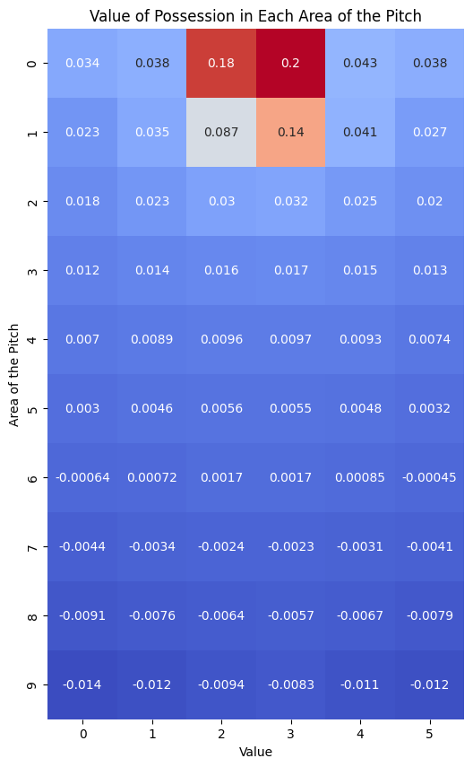

```python
# Let's do a visualization of how valuable it is to have the ball in each area of the pitch\
VALUES = np.zeros((PORTIONS_OF_PITCH_LENGTHWISE, PORTIONS_OF_PITCH_WIDTHWISE))
for i in range(PORTIONS_OF_PITCH):

    # Calculate the average value for the area, weighted by the number of instances
    values = expected_value[HOME_TEAM_SUCCESSFUL_PASS + 2*i]
    VALUES[PORTIONS_OF_PITCH_LENGTHWISE-(i//PORTIONS_OF_PITCH_WIDTHWISE)-1][PORTIONS_OF_PITCH_WIDTHWISE-(i%PORTIONS_OF_PITCH_WIDTHWISE)-1] = values


plt.figure(figsize=(PORTIONS_OF_PITCH_WIDTHWISE, PORTIONS_OF_PITCH_LENGTHWISE))
sns.heatmap(VALUES, cmap="coolwarm", annot=True, cbar=False)
plt.xticks(ticks=np.arange(PORTIONS_OF_PITCH_WIDTHWISE) + 0.5)
plt.yticks(ticks=np.arange(PORTIONS_OF_PITCH_LENGTHWISE) + 0.5)
plt.title("Value of Possession in Each Area of the Pitch")
plt.xlabel("Value")
plt.ylabel("Area of the Pitch")
plt.show()
```

**Now Useless Visualizations (2 cells)**

#### Now Useless Visualizations

[figure not shown]

```python
import networkx as nx

def create_markov_graph(transition_matrix):
    """
    Create a directed graph from the transition matrix.

    Args:
        transition_matrix (np.ndarray): Transition matrix (n x n).

    Returns:
        nx.DiGraph: Directed graph representing the Markov chain.
    """
    G = nx.DiGraph()
    n = transition_matrix.shape[0]

    for i in range(n):
        for j in range(n):
            if transition_matrix[i][j] > 0:
                G.add_edge(i, j, weight=round(transition_matrix[i][j], 4))  # Round to 4 decimal places for clarity

    return G

def draw_markov_graph(G, expected_values):
    """
    Draw the Markov chain graph with expected values as node labels.

    Args:
        G (nx.DiGraph): Directed graph representing the Markov chain.
        expected_values (np.ndarray): Expected values for each state.
    """
    pos = nx.spring_layout(G)
    labels = {i: f"{i}\nEV: {expected_values[i]:.2f}" for i in G.nodes()}

    plt.figure(figsize=(10, 8))
    nx.draw(G, pos, with_labels=True, labels=labels, node_size=2000, node_color='lightblue', font_size=10, font_color='black', arrows=True)
    edge_labels = nx.get_edge_attributes(G, 'weight')
    nx.draw_networkx_edge_labels(G, pos, edge_labels=edge_labels)

    plt.title("Markov Chain Graph with Expected Values")
    plt.show()

# Create the Markov chain graph
G = create_markov_graph(transition_matrix)
# Draw the Markov chain graph with expected values
draw_markov_graph(G, expected_value)
```

[figure not shown]

```python
# Create a visualization of the expected values
plt.figure(figsize=(10, 6))
sns.heatmap(transition_matrix, annot=True, fmt=".2f", cmap="coolwarm", cbar_kws={'label': 'Transition Probability'})
plt.title("Transition Matrix Heatmap")
plt.xlabel("Next State")
plt.ylabel("Current State")
plt.xticks(ticks=np.arange(6) + 0.5, labels=[
    "Home Goal", "Away Goal", "Home Successful Pass",
    "Away Successful Pass", "Home Unsuccessful Pass",
    "Away Unsuccessful Pass"], rotation=45)
plt.yticks(ticks=np.arange(6) + 0.5, labels=[
    "Home Goal", "Away Goal", "Home Successful Pass",
    "Away Successful Pass", "Home Unsuccessful Pass",
    "Away Unsuccessful Pass"], rotation
=45)
plt.tight_layout()
plt.show()
```

**So, Who Has Added the Most Value via His Passing? (2 cells)**

## So, Who Has Added the Most Value via His Passing?

Admittedly, we are using Premier League 2020-21 data for this. We will expand on this, but importing new data takes space I don't really have

```python
TEST_PRINT = True
players = dict()

"""
game_id                int64
period                object
minute                 int64
second               float64
expanded_minute        int64
type                  object
outcome_type          object
team_id                int64
team                  object
player_id            float64
player                object
x                    float64
y                    float64
end_x                float64
end_y                float64
goal_mouth_y         float64
goal_mouth_z         float64
blocked_x            float64
blocked_y            float64
qualifiers            object
is_touch                bool
is_shot               object
is_goal               object
card_type             object
related_event_id     float64
related_player_id    float64
"""
for _, event in api.iterrows():
    if pd.notna(event["player_id"]):
        player_id = int(event["player_id"])
        if player_id not in players:
            players[player_id] = {
                "name": event["player"],
                "team": event["team"],
                "goals": 0,
                "assists": 0,
                "xGA" : 0,  # Expected Goals Added via Passing
            }
        if event["is_goal"] == True:
            players[player_id]["goals"] += 1
        if event["type"] == "Pass":
            players[player_id]["xGA"] += get_xga(event)

# Convert the players dictionary to a DataFrame
players_df = pd.DataFrame.from_dict(players, orient='index')

# Sort the DataFrame by goals and xGA
players_df = players_df.sort_values(by=["xGA"], ascending=False)
players_df
```

[output not shown]

```python
type(api)
```

```
pandas.core.frame.DataFrame
```